# AMD core microbes, plots

## 2. Core at the chosen gate and recovery

```r
by_level <- map(levels, \(l) filter(prevalence_grid, gate_ih == gate_ih_min, recov_ih == recov_ih_min,
                                    method == "recovered", level == l)) %>%
  set_names(levels)
core <- map(by_level, \(d) filter(d, freq >= min_freq))

for (l in levels) {
  cat(sprintf("%s: %d core %s at >= %.1f%% prevalence (of %d detected)\n",
              l, nrow(core[[l]]), plural[[l]], min_freq * 100, nrow(by_level[[l]])))
}
```

```
## species: 19117 core species at >= 90.0% prevalence (of 23685 detected)
## genus: 7198 core genera at >= 90.0% prevalence (of 8095 detected)
```

```r
for (l in levels) {
  cat("\nCore", plural[[l]], "\n")
  core[[l]] %>% select(taxon, n_present, freq) %>% print(n = 30)
}
```

```
##
## Core species
## # A tibble: 19,117 × 3
##    taxon                             n_present  freq
##    <chr>                                 <int> <dbl>
##  1 s__13-2-20CM-66-19 sp021815925          103     1
##  2 s__13-2-20CM-66-19 sp021849615          103     1
##  3 s__13-2-20CM-66-19 sp028067895          103     1
##  4 s__13-2-20CM-66-19 sp034668025          103     1
##  5 s__20CM-2-55-15 sp003222755             103     1
##  6 s__20CM-2-55-15 sp003223895             103     1
##  7 s__54-19 sp001898225                    103     1
##  8 s__AG-12 sp013044295                    103     1
##  9 s__AM-0621 sp021732995                  103     1
## 10 s__ARS98 sp030430075                    103     1
```

[output cut: 57 more lines]

## 3. Recovery gain

Recovered at the chosen gate and recovery, compared with strict-only at the same gate. A full join keeps taxa found only by strict-only, so negative gains show up too. Those come from genomes that meet the gate in fewer than `gate_min_srr` metagenomes: strict-only counts them, but they aren’t eligible for recovery.

```r
strict_by_level <- map(levels, \(l) filter(prevalence_grid, gate_ih == gate_ih_min,
                                           method == "strict only", level == l)) %>%
  set_names(levels)

gain_at <- function(l) {
  full_join(by_level[[l]]        %>% select(taxon, freq_recovered = freq),
            strict_by_level[[l]] %>% select(taxon, freq_strict    = freq),
            by = "taxon") %>%
    mutate(across(c(freq_recovered, freq_strict), \(x) replace_na(x, 0)),
           gain = freq_recovered - freq_strict) %>%
    arrange(desc(gain))
}

gains <- map(levels, gain_at) %>% set_names(levels)

for (l in levels) {
  g <- gains[[l]]
  cat(sprintf("\n%s: %d gained, %d unchanged, %d lost (median gain %.2f)\n",
              l, sum(g$gain > 0), sum(g$gain == 0), sum(g$gain < 0), median(g$gain)))
  cat("Top 10 gains\n")
  print(head(g, 10))
}
```

```
##
## species: 23682 gained, 3 unchanged, 13748 lost (median gain 0.78)
## Top 10 gains
## # A tibble: 10 × 4
##    taxon                         freq_recovered freq_strict  gain
##    <chr>                                  <dbl>       <dbl> <dbl>
##  1 s__Alistipes merdipullorum                 1      0.0291 0.971
##  2 s__Anaerotruncus colihominis               1      0.0291 0.971
##  3 s__Angelobacter sp041493865                1      0.0291 0.971
##  4 s__Bacillus_A paramycoides                 1      0.0291 0.971
##  5 s__Blautia_A caecimuris                    1      0.0291 0.971
##  6 s__Chitinophaga sp019219075                1      0.0291 0.971
##  7 s__Endoriftia persephone                   1      0.0291 0.971
##  8 s__Fen-1298 sp003819715                    1      0.0291 0.971
##  9 s__Flavobacterium sp012270005              1      0.0291 0.971
## 10 s__Formimonas warabiya                     1      0.0291 0.971
##
## genus: 8091 gained, 4 unchanged, 3423 lost (median gain 0.80)
## Top 10 gains
## # A tibble: 10 × 4
##    taxon         freq_recovered freq_strict  gain
##    <chr>                  <dbl>       <dbl> <dbl>
##  1 s__Endoriftia              1      0.0291 0.971
##  2 s__Fen-1298                1      0.0291 0.971
##  3 s__Formimonas              1      0.0291 0.971
##  4 s__JAAYPC01                1      0.0291 0.971
##  5 s__JACKPC01                1      0.0291 0.971
##  6 s__JADGAN01                1      0.0291 0.971
##  7 s__JAKSCG01                1      0.0291 0.971
##  8 s__JAQTZZ01                1      0.0291 0.971
##  9 s__JARFUG01                1      0.0291 0.971
## 10 s__RGIG5021                1      0.0291 0.971
```

## 4. Core counts

`series` labels each column: “recov 1”, “recov 3”, and so on for the recovered method, and “strict only”.

```r
series_levels <- c(paste("recov", recov_cuts), "strict only")

core_counts <- prevalence_grid %>%
  crossing(min_freq = freq_cuts) %>%
  summarize(n_core = sum(freq >= min_freq), .by = c(level, method, gate_ih, recov_ih, min_freq)) %>%
  mutate(series = factor(if_else(method == "strict only", "strict only", paste("recov", recov_ih)),
                         levels = series_levels))

for (l in levels) {
  cat("\nCore", plural[[l]], "by gate, recovery, and prevalence cutoff (blank = recovery above gate)\n")
  core_counts %>%
    filter(level == l) %>%
    select(gate_ih, min_freq, series, n_core) %>%
    pivot_wider(names_from = series, values_from = n_core, names_sort = TRUE) %>%
    arrange(min_freq, gate_ih) %>%
    print(n = Inf)
}
```

```
##
## Core species by gate, recovery, and prevalence cutoff (blank = recovery above gate)
## # A tibble: 25 × 7
##    gate_ih min_freq `recov 1` `recov 3` `recov 10` `recov 20` `strict only`
##      <int>    <dbl>     <int>     <int>      <int>      <int>         <int>
##  1       3    0.8       94457     11316         NA         NA         11316
##  2      10    0.8       76913     11316        347         NA           347
##  3      20    0.8       22963      9519        347        126           126
##  4      50    0.8        3237      1658        341        126            43
##  5      75    0.8        2349      1108        304        126            24
##  6       3    0.85      74400      5766         NA         NA          5766
##  7      10    0.85      65741      5766        204         NA           204
##  8      20    0.85      22087      5336        204         78            78
##  9      50    0.85       2939      1275        204         78            20
## 10      75    0.85       2112       816        187         78             8
```

[output cut: 45 more lines]

## 5. Plotmaxxing

# Species

## Plot A: Species core size, strict vs recovered

Bars stack strict-only counts with the taxa added by recovery. The number is the total recovered core size. Gates below recov_ih_min have no recovered run, so they show strict only.

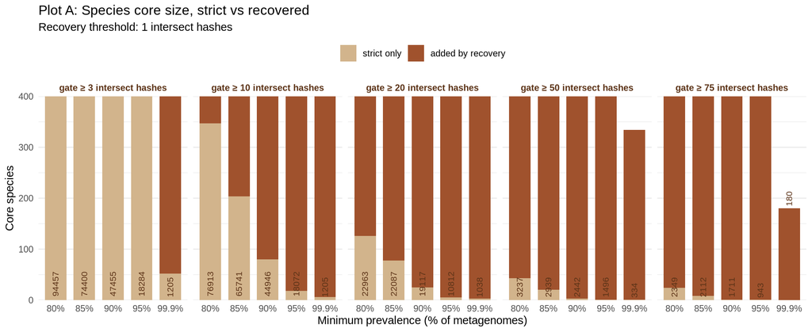

```r
species_stack <- core_counts %>%
  # species rows, strict plus recovered at the chosen recovery threshold
  filter(level == "species", method == "strict only" | recov_ih == recov_ih_min) %>%
  select(gate_ih, min_freq, method, n_core) %>%
  # one row per gate x cutoff, with strict and recovered counts side by side
  pivot_wider(names_from = method, values_from = n_core) %>%
  # gates below recov_ih_min have no recovered run, so fall back to strict
  mutate(recovered = coalesce(recovered, `strict only`),
         # the slice recovery adds on top of strict
         `added by recovery` = recovered - `strict only`)

species_stack_long <- species_stack %>%
  # back to long, one row per bar segment, for stacking
  pivot_longer(c(`strict only`, `added by recovery`),
               names_to = "component", values_to = "n") %>%
  # factor order controls stacking: last level sits at the bottom
  mutate(component = factor(component, levels = c("added by recovery", "strict only")))

ggplot(species_stack_long, aes(x = factor(min_freq), y = n, fill = component)) +
  geom_col(width = 0.75) +
  # totals over 200: label inside the bar, at the bottom
  geom_text(data = filter(species_stack, recovered > 200),
            aes(x = factor(min_freq), y = 0, label = recovered),
            inherit.aes = FALSE, angle = 90, hjust = -0.15, size = 3, color = "#5C3317") +
  # totals 200 or under: label above the bar
  geom_text(data = filter(species_stack, recovered <= 200),
            aes(x = factor(min_freq), y = recovered, label = recovered),
            inherit.aes = FALSE, angle = 90, hjust = -0.15, size = 3, color = "#5C3317") +
  scale_fill_manual(values = c("strict only" = "#D2B48C", "added by recovery" = "#A0522D"),
                    breaks = c("strict only", "added by recovery")) +
  scale_x_discrete(labels = \(x) paste0(as.numeric(x) * 100, "%")) +
  scale_y_continuous(expand = c(0, 0)) +
  coord_cartesian(ylim = c(0, 400)) +
  facet_wrap(~ gate_ih, nrow = 1,
             labeller = labeller(gate_ih = \(x) paste0("gate ≥ ", x, " intersect hashes"))) +
  labs(x = "Minimum prevalence (% of metagenomes)", y = "Core species", fill = NULL,
       title = "Plot A: Species core size, strict vs recovered",
       subtitle = sprintf("Recovery threshold: %d intersect hashes", recov_ih_min)) +
  theme_minimal() +
  theme(legend.position = "top",
        strip.text = element_text(face = "bold", color = "#5C3317"),
        panel.grid.major.x = element_blank())
```

## Plot B: Species core size by recovery threshold

One line per recovery threshold. The dashed tan line is strict only, for reference.

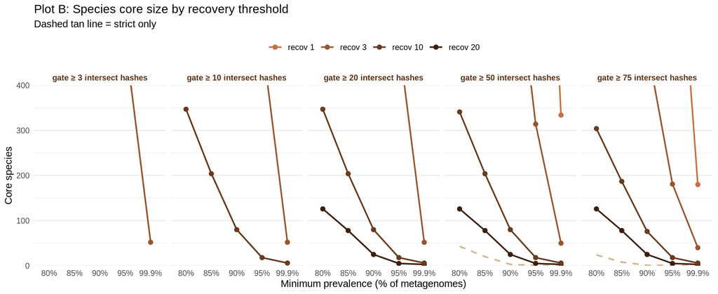

```r
# one sienna-to-dark-brown color per recovery threshold, named to match the series column
recov_colors <- setNames(colorRampPalette(c("#C8703F", "#3B1F0E"))(length(recov_cuts)),
                         paste("recov", recov_cuts))

# recovered rows, one line per recovery threshold
species_lines  <- core_counts %>% filter(level == "species", method == "recovered")
# strict rows, drawn as the dashed reference line
species_strict <- core_counts %>% filter(level == "species", method == "strict only")

ggplot(species_lines, aes(x = factor(min_freq), y = n_core, color = series, group = series)) +
  geom_line(data = species_strict,
            aes(x = factor(min_freq), y = n_core, group = 1),
            inherit.aes = FALSE, color = "#D2B48C", linetype = "dashed", linewidth = 0.8) +
  geom_line(linewidth = 0.8) +
  geom_point(size = 2) +
  scale_color_manual(values = recov_colors) +
  scale_x_discrete(labels = \(x) paste0(as.numeric(x) * 100, "%")) +
  scale_y_continuous(expand = c(0, 0)) +
  coord_cartesian(ylim = c(0, 400)) +
  facet_wrap(~ gate_ih, nrow = 1,
             labeller = labeller(gate_ih = \(x) paste0("gate ≥ ", x, " intersect hashes"))) +
  labs(x = "Minimum prevalence (% of metagenomes)", y = "Core species", color = NULL,
       title = "Plot B: Species core size by recovery threshold",
       subtitle = "Dashed tan line = strict only") +
  theme_minimal() +
  theme(legend.position = "top",
        strip.text = element_text(face = "bold", color = "#5C3317"),
        panel.grid.major.x = element_blank())
```

# Genus

## Plot C: Genus core size, strict vs recovered

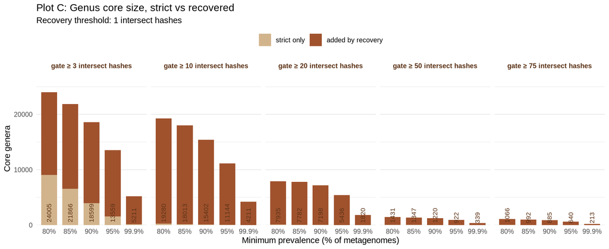

```r
genus_stack <- core_counts %>%
  # genus rows, strict plus recovered at the chosen recovery threshold
  filter(level == "genus", method == "strict only" | recov_ih == recov_ih_min) %>%
  select(gate_ih, min_freq, method, n_core) %>%
  # one row per gate x cutoff, with strict and recovered counts side by side
  pivot_wider(names_from = method, values_from = n_core) %>%
  # gates below recov_ih_min have no recovered run, so fall back to strict
  mutate(recovered = coalesce(recovered, `strict only`),
         # the slice recovery adds on top of strict
         `added by recovery` = recovered - `strict only`)

genus_stack_long <- genus_stack %>%
  # back to long, one row per bar segment, for stacking
  pivot_longer(c(`strict only`, `added by recovery`),
               names_to = "component", values_to = "n") %>%
  # factor order controls stacking: last level sits at the bottom
  mutate(component = factor(component, levels = c("added by recovery", "strict only")))

ggplot(genus_stack_long, aes(x = factor(min_freq), y = n, fill = component)) +
  geom_col(width = 0.75) +
  # totals over 200: label inside the bar, at the bottom
  geom_text(data = filter(genus_stack, recovered > 200),
            aes(x = factor(min_freq), y = 0, label = recovered),
            inherit.aes = FALSE, angle = 90, hjust = -0.15, size = 3, color = "#5C3317") +
  # totals 200 or under: label above the bar
  geom_text(data = filter(genus_stack, recovered <= 200),
            aes(x = factor(min_freq), y = recovered, label = recovered),
            inherit.aes = FALSE, angle = 90, hjust = -0.15, size = 3, color = "#5C3317") +
  scale_fill_manual(values = c("strict only" = "#D2B48C", "added by recovery" = "#A0522D"),
                    breaks = c("strict only", "added by recovery")) +
  scale_x_discrete(labels = \(x) paste0(as.numeric(x) * 100, "%")) +
  scale_y_continuous(expand = expansion(mult = c(0, 0.15))) +
  facet_wrap(~ gate_ih, nrow = 1,
             labeller = labeller(gate_ih = \(x) paste0("gate ≥ ", x, " intersect hashes"))) +
  labs(x = "Minimum prevalence (% of metagenomes)", y = "Core genera", fill = NULL,
       title = "Plot C: Genus core size, strict vs recovered",
       subtitle = sprintf("Recovery threshold: %d intersect hashes", recov_ih_min)) +
  theme_minimal() +
  theme(legend.position = "top",
        strip.text = element_text(face = "bold", color = "#5C3317"),
        panel.grid.major.x = element_blank())
```

## Plot D: Genus core size by recovery threshold

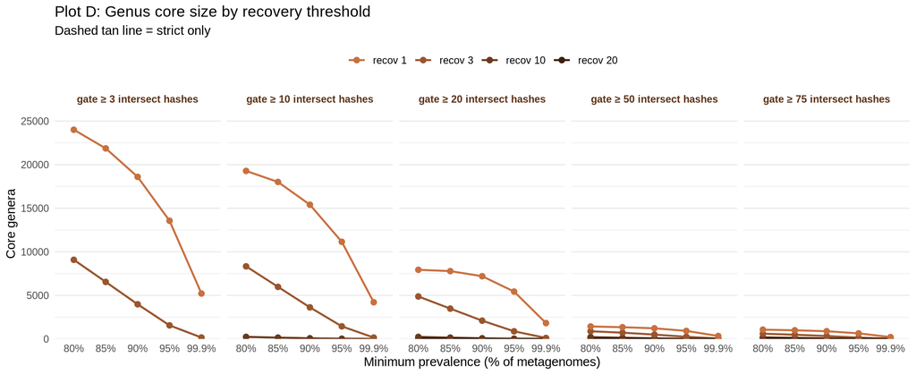

```r
# recovered rows, one line per recovery threshold (recov_colors comes from Plot B)
genus_lines  <- core_counts %>% filter(level == "genus", method == "recovered")
# strict rows, drawn as the dashed reference line
genus_strict <- core_counts %>% filter(level == "genus", method == "strict only")

ggplot(genus_lines, aes(x = factor(min_freq), y = n_core, color = series, group = series)) +
  geom_line(data = genus_strict,
            aes(x = factor(min_freq), y = n_core, group = 1),
            inherit.aes = FALSE, color = "#D2B48C", linetype = "dashed", linewidth = 0.8) +
  geom_line(linewidth = 0.8) +
  geom_point(size = 2) +
  scale_color_manual(values = recov_colors) +
  scale_x_discrete(labels = \(x) paste0(as.numeric(x) * 100, "%")) +
  scale_y_continuous(expand = expansion(mult = c(0, 0.1))) +
  facet_wrap(~ gate_ih, nrow = 1,
             labeller = labeller(gate_ih = \(x) paste0("gate ≥ ", x, " intersect hashes"))) +
  labs(x = "Minimum prevalence (% of metagenomes)", y = "Core genera", color = NULL,
       title = "Plot D: Genus core size by recovery threshold",
       subtitle = "Dashed tan line = strict only") +
  theme_minimal() +
  theme(legend.position = "top",
        strip.text = element_text(face = "bold", color = "#5C3317"),
        panel.grid.major.x = element_blank())
```

## Get species names

```r
core_strict_20 <- read_csv("intermediate_files/core_prevalence/prevalence_grid.csv", show_col_types = FALSE) %>%
  filter(level == "species", method == "strict only", gate_ih == 20, freq >= 0.90) %>%
  select(taxon, n_present, freq) %>%
  arrange(desc(freq)) |>
  select(taxon)

write_csv(core_strict_20, "intermediate_files/core_prevalence/core_species_strict_gate20_freq90.csv")
```

## Ideas

- Core by region or by metal contaminant?
- Are there categories of AMD? Suspected founder taxa?
- Have any sites been bioremediated?